# HPLC: compare standards

Author

Tom Zaplana, Andrew Tolonen

# Introduction

This notebook compares the peak areas from HPLC standards using ChromConverter and Lab Solutions .txt files. The HPLC files include data from 3 channels (below). For these analyses, we will focus only on the data from detector B (RID).

1. Detector A-Ch1: UV/VIS SPD-20A detector at 260 nm.
2. Detector A-Ch2: UV/VIS SPD-20A detector at 210 nm. Acids (ie acetate) are visible using channel 2.
3. Detector B: Refractive index RID-10A.

We compare the chromatograms for 5 concentrations of metabolites (STD1-5) (see table below). First, we will compare the chromatograms for Lab Solutions .txt files versus Chromconverter-converted .lcd files. We will then calculate peak areas for each file type and plot the linearity of the standard curves. The output is a file containing parameters of the linear models (slope, intercept) to calculate metabolite concentrations from the peak areas.

```r
datafile = "/home/tolonen/Github/actolonen/Public/Analysis_Lab/Metabolites/HPLC/Standards/information.xlsx";
standards = read_excel(datafile, sheet = "Standards", col_names = TRUE);

table.standards = kable(standards, caption = "Table: Metabolite concentrations in standards");
table.standards
```

Table: Metabolite concentrations in standards

| Sample | Metabolite | mM |
| --- | --- | --- |
| STD5 | Acetate | 50.000000 |
| STD5 | Ethanol | 342.500000 |
| STD5 | Lactate | 50.000000 |
| STD5 | Glucose | 27.775000 |
| STD5 | Cellobiose | 27.775000 |
| STD4 | Acetate | 25.000000 |
| STD4 | Ethanol | 171.250000 |
| STD4 | Lactate | 25.000000 |
| STD4 | Glucose | 13.887500 |
| STD4 | Cellobiose | 13.887500 |
| STD3 | Acetate | 12.500000 |
| STD3 | Ethanol | 85.625000 |
| STD3 | Lactate | 12.500000 |
| STD3 | Glucose | 6.943750 |
| STD3 | Cellobiose | 6.943750 |
| STD2 | Acetate | 6.250000 |
| STD2 | Ethanol | 42.812500 |
| STD2 | Lactate | 6.250000 |
| STD2 | Glucose | 3.471875 |
| STD2 | Cellobiose | 3.471875 |
| STD1 | Acetate | 3.125000 |
| STD1 | Ethanol | 21.406250 |
| STD1 | Lactate | 3.125000 |
| STD1 | Glucose | 1.735937 |
| STD1 | Cellobiose | 1.735937 |

```r
# adapt to this dataset with duplicates
standards1 = standards %>%
  mutate(samplenum = "-1") %>%
  unite("Sample", Sample, samplenum, sep="");
standards2 = standards %>%
  mutate(samplenum = "-2") %>%
  unite("Sample", Sample, samplenum, sep="");
standards = rbind(standards1, standards2);
```

# Functions

## Calc peak areas

Calculate peak areas for a metabolite. Returns list: chromatogram peaks for all samples, peak areas for all samples.

```r
calc_peakAreas = function(peak.start, peak.end, data.all)
{
#  get list of samples
sample.list = unique(data.all$Sample);

# declare dataframes for peaks and areas
peaks.all = data.frame(Minutes = double(),
                           Intensity = double(),
                           Sample = character(),
                           Replicate = character(),
                           Format = character());

areas.all = data.frame(SampleID = character(),
                       Area = double(),
                       Method = character());

for (SampleID in sample.list)
{

# calc background as mode measurement
data.temp = data.all %>%
  filter(Format == "LabSolutions") %>%
  filter(Sample == SampleID);
background.ls = modeest::mfv(round(data.temp$Intensity, digits = 1));

data.temp = data.all %>%
  filter(Format == "ChromConverter") %>%
    filter(Sample == SampleID);
background.cc = modeest::mfv(round(data.temp$Intensity, digits = 1));

 # get chromatogram for peak
 data.peak = data.all %>%
   filter(Sample == SampleID) %>%
   filter(Minutes > peak.start & Minutes < peak.end) %>%
   separate(Sample, c("Sample", "Replicate"), sep = "-");

 peaks.all = rbind(peaks.all, data.peak);

 # calc peak areas: cc and ls
 Method = "ChromConverter";
 data.temp = data.peak %>%
   filter(Format == Method) %>%
   mutate(Intensity_diff = Intensity - background.cc);
 Area = AUC(data.temp$Minutes, data.temp$Intensity_diff, method='trapezoid');
 area.sample = data.frame(SampleID, Area, Method);
 areas.all = rbind(areas.all, area.sample);

 Method = "LabSolutions";
 data.temp = data.peak %>%
   filter(Format == Method) %>%
   mutate(Intensity_diff = Intensity - background.ls);
 #Area = sum(data.temp$Intensity_diff);
  Area = AUC(data.temp$Minutes, data.temp$Intensity_diff, method='trapezoid');
 area.sample = data.frame(SampleID, Area, Method);
 areas.all = rbind(areas.all, area.sample);
}

# return data as a list
peakData = list(peaks.all, areas.all);
return(peakData);
}
```

# Methods

## LS: extract detector B

Perl to extract detector B chromatograms from Lab Solutions .txt files. Prints detector B .txt files

```perl
# perl code to extract detector B chromatograms from LabSolutions .txt files. Outputs
# detector B chromatograms as .txt files.

$dirpath = "/home/tolonen/Github/actolonen/Public/Analysis_Lab/Metabolites/HPLC/Standards/Files_TXT";

# get list of .txt files
opendir(DIR, $dirpath) or die "cannot open directory $dirpath\n";
@allfiles = grep(/STD.*\.txt$/, readdir(DIR));

# remove cleaned files from previous runs
foreach $file (@allfiles)
{
 if ($file =~ /detector/)
 {
  $inputfile = "$dirpath"."/"."$file";
  unlink($inputfile);
 }
}

# extract detector B (RID) chromatogram
LOOP:foreach $file (@allfiles)
{
 $inputfilepath = "$dirpath"."/"."$file";
 $file =~ /(.*).txt/;
 $inputfilebase = $1;
 $outputfile = "$inputfilebase"."_detectorB.txt";
 $outputfilepath = "$dirpath"."/DetectorB/"."$outputfile";
 open(IN, "<$inputfilepath") or die "cant open IN\n";
 open(OUT, ">$outputfilepath") or die "cant open OUT\n";
 while ($line = <IN>)
 {
  chomp($line);
  $line =~ s/\r//g;
  unless ($line =~ /LC Chromatogram\(Detector B-Ch1\)/)
  {
   next;
  }
  until ($line =~ /^R.Time/)
  {
    $line = <IN>;
    chomp($line);
    $line =~ s/\r//g;
  }
  print OUT "$line\n";
  $line = <IN>;
  until($line =~ /[a-z]/)
 {
  chomp($line);
  $line =~ s/\r//g;
  print OUT "$line\n";
  $line = <IN>;
 }
next LOOP;
}
close IN;
close OUT;
}
```

## CC: convert .lcd to .txt

ChromConverter to read .lcd files and output detector B .txt files.

```r
# get a list of .lcd files in the working directory and convert them to data.frames,
# then print the data.frmes as .txt files.

input.dir = "/home/tolonen/Github/actolonen/Public/Analysis_Lab/Metabolites/HPLC/Standards/Files_LCD";
files.lcd = list.files(path = input.dir, pattern = "STD");
output.dir = "/home/tolonen/Github/actolonen/Public/Analysis_Lab/Metabolites/HPLC/Standards/Files_LCD/Output/";

# declare empty data.frame
data_cc = data.frame(Minutes = double(),
                      Intensity = double(),
                      Sample = character());

for (file in files.lcd)
{
  inputfile = paste(input.dir, file, sep = "/");
  inputfile.base = str_replace(string=file, pattern=".lcd", replacement = "");
  data = read_shimadzu_lcd(
     path = inputfile,
     format_out = "data.frame",
     data_format = "long",
     read_metadata = TRUE);
  mydata = data; # make a personal copy
  mydata = mydata %>%
    rownames_to_column(var = "Minutes") %>%
    rename(Intensity = int) %>%
    mutate(Sample=inputfile.base); # add col of sample
  data_cc = rbind(data_cc, mydata); # make df of all samples
  outputfile = paste(output.dir, inputfile.base, "_chromConverter_RID-10A_Detector_B.txt", sep = "");
  write.csv(data_cc, file = outputfile);
}
```

# Results

Make data.frame of chromatograms produced by chromConverter() and LabSolutions

```r
# foreach headerless .txt file in LabSolutions directory, grab file base name, open filehandles to LabSolutions and chromConverter files base file name, plot both files on same plot.

# directories of input files
input.dir.ls = "/home/tolonen/Github/actolonen/Public/Analysis_Lab/Metabolites/HPLC/Standards/Files_TXT/DetectorB";
input.dir.cc = "/home/tolonen/Github/actolonen/Public/Analysis_Lab/Metabolites/HPLC/Standards/Files_LCD/Output";

# read cc data into data frame
files.cc = list.files(path = input.dir.cc, pattern = "chromConverter_RID-10A_Detector_B.txt");

# declare empty data.frame
data.all= data.frame(Minutes = double(),
                     Intensity = double(),
                     Sample = character(),
                     Format = character());

for (file in files.cc)
{
  path.cc = paste(input.dir.cc, file, sep = "/");
  inputfile.cc.base = str_replace(string=file, pattern="_chromConverter_RID-10A_Detector_B.txt", replacement = "");
  data.cc = read.csv(file = path.cc, header=TRUE);

# cleanup input data
data.cc = data.cc %>%
  select(Minutes, Intensity, Sample) %>%
  mutate(Format = "ChromConverter");

data.all = rbind(data.all, data.cc);
}

# read ls data into data frame
files.ls = list.files(path = input.dir.ls, pattern = "detectorB.txt");

for (file in files.ls)
{
  path.ls = paste(input.dir.ls, file, sep = "/");
  inputfile.ls.base = str_replace(string=file, pattern="_detectorB.txt", replacement="");
  data.ls = read.csv(file = path.ls, header=TRUE, sep = "\t");

# clean up data
data.ls = data.ls %>%
  rename(Minutes = R.Time..min.) %>%
  mutate(Format = "LabSolutions") %>%
  mutate(Minutes = as.numeric(Minutes)) %>%
  mutate(Intensity = as.numeric(Intensity)) %>%
  mutate(Sample = inputfile.ls.base) %>%
  drop_na();

# data.ls = data.ls %>%
#   mutate(Intensity = (0.1 * Intensity));

# concatenate data from two files
data.all = rbind(data.all, data.ls);

}
```

## Table comparing max peak heights

```r
sample.list = unique(data.all$Sample);

# declare empty data.frame
data.table.all = data.frame(Sample = character(),
                     Intensity_cc = double(),
                     Intensity_ls = double(),
                     Ratio = double());

for (mysample in sample.list)
{
  data.table = data.all %>%
    filter(Sample == mysample);

  data.cc.sample = data.table %>%
    filter(Format == "ChromConverter");
  max.cc = max(data.cc.sample$Intensity);

  data.ls.sample = data.table %>%
    filter(Format == "LabSolutions");
  max.ls = max(data.ls.sample$Intensity);

  ratio = max.ls/max.cc;

  data.table.sample = data.frame(mysample, max.cc, max.ls, ratio);

  data.table.all = rbind(data.table.all, data.table.sample);
}

table1 = kable(data.table.all, caption = "Table: Comparison of max peak heights for each sample analyzed using ChromConverter and LabSolutions. The mean ratio (chromConverter/LabSolutions) was applied to all subsequent ChromConverter analyses.");
table1
```

| mysample | max.cc | max.ls | ratio |
| --- | --- | --- | --- |
| STD1-1 | 11153.582 | 36032 | 3.230532 |
| STD1-2 | 630.593 | 2037 | 3.230293 |
| STD2-1 | 1401.991 | 4529 | 3.230406 |
| STD2-2 | 1324.261 | 4278 | 3.230481 |
| STD3-1 | 3616.329 | 11683 | 3.230624 |
| STD3-2 | 3528.950 | 11401 | 3.230706 |
| STD4-1 | 8094.699 | 26151 | 3.230633 |
| STD4-2 | 8028.430 | 25936 | 3.230520 |
| STD5-1 | 17033.011 | 55026 | 3.230550 |
| STD5-2 | 17033.324 | 55027 | 3.230550 |

```r
# transform cc intensities by mean ratio
ratio.mean = mean(data.table.all$ratio);
data.all = data.all %>%
  mutate(Intensity = case_when(Format == "ChromConverter" ~ Intensity * ratio.mean, Format == "LabSolutions" ~ Intensity));
```

## Plot chromatograms

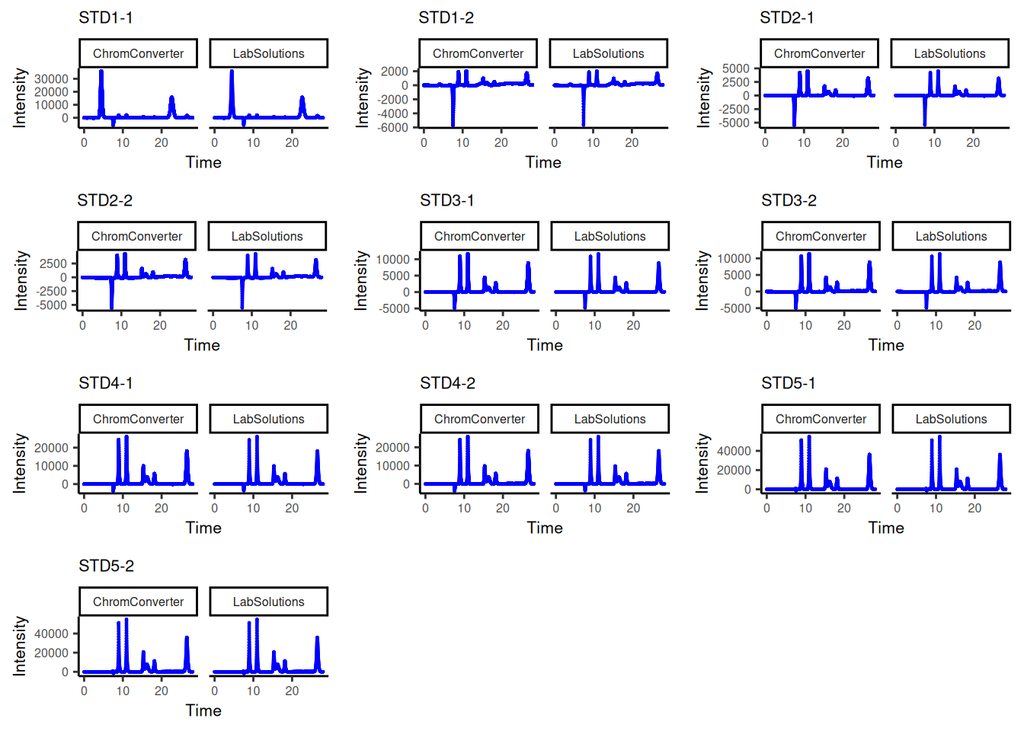

Chromatograms built using Lab Solutions and ChromConverter for each standard sample: 5 concentrations, 2 replicates.

```r
sample.list = unique(data.all$Sample);
chromatograms.all <- list()  # new empty list

counter = 1;
for (mysample in sample.list)
{
 data.plot = data.all %>%
   filter(Sample == mysample);

 myplot = ggplot(data.plot, aes(x=Minutes, y=Intensity)) +
  ggtitle(mysample)+
  geom_point(size=0.1, color = 'blue') +
  xlab("Time") +
  ylab("Intensity") +
  theme_classic() +
  facet_wrap(~ Format)+
  theme_classic()+
  mytheme;

  chromatograms.all[[counter]] = myplot;  # add each plot into plot list
  counter = counter+1;
}
 chromatograms.all.plots = grid.arrange(grobs = chromatograms.all);
```

```r
 #chromatograms.all.plots
```

## Metabolite concentrations

```r
# declare output table with regression information to calculate concentrations from peak
# areas in experimental samples.

# compound_mM = Slope.reg * peak.area + Intercept.reg;

regressions.out = data.frame(
    Compound = character(),
    Method = character(),
    Slope.reg = double(),
    Intercept.reg = double(),
    peak.start = double(),
    peak.end = double()
);
```

### Acetate

Calc peak areas

```r
# compound parameters
Compound = "Acetate";
peak.start = 17.75;
peak.end = 18.6;

# get the chromatogram peaks and calculate the areas for each sample
peakData = calc_peakAreas(peak.start, peak.end, data.all);
peaks.all = peakData[[1]];
areas.all = peakData[[2]];

# add standard concentrations to peak areas
standards.compound = standards %>%
  filter(Metabolite == Compound) %>%
  rename(SampleID = Sample);
areas.all.concs = left_join(areas.all, standards.compound, by="SampleID");
```

Calc regressions

```r
# LS data: regression
target.method = "LabSolutions";

areas.all.ls = areas.all.concs %>%
  filter(Method == target.method);

my.lm = lm(mM ~ Area, areas.all.ls);
yint = my.lm$coefficients[1];
myslope = my.lm$coefficients[2];
myslope.text = formatC(myslope, format = "e", digits = 2);
regression.ls = data.frame(Compound, target.method, myslope, yint, peak.start, peak.end);
regressions.out = rbind(regressions.out, regression.ls);
regtext.ls = paste("mM product = ", myslope.text, "* Area + ", round(yint, 3), sep="");

# CC data: regression
target.method = "ChromConverter";
areas.all.cc = areas.all.concs %>%
  filter(Method == target.method);

my.lm = lm(mM ~ Area, areas.all.cc);
yint = my.lm$coefficients[1];
myslope = my.lm$coefficients[2];
myslope.text = formatC(myslope, format = "e", digits = 2);
regression.cc = data.frame(Compound, target.method, myslope, yint, peak.start, peak.end);
regressions.out = rbind(regressions.out, regression.cc);
regtext.cc = paste("mM product = ", myslope.text, "* Area + ", round(yint, 3), sep="");
```

Plot peaks

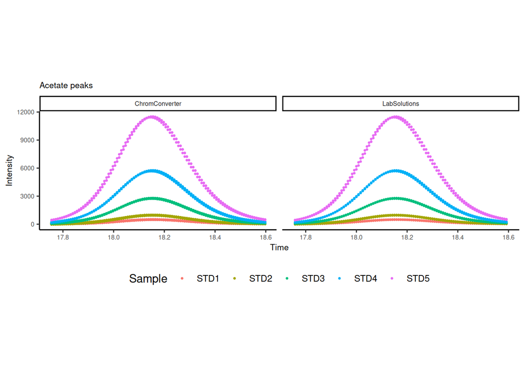

Peak areas of acetate in each of the standards samples.

```r
# plot peaks
 myplot = ggplot(peaks.all, aes(x=Minutes, y=Intensity, group=Sample, color=Sample)) +
  ggtitle(paste(Compound, " peaks", sep=""))+
  geom_point(size=0.5) +
  xlab("Time") +
  ylab("Intensity") +
  coord_cartesian(xlim=c(peak.start, peak.end), ylim=c(min(peaks.all$Intensity), max(peaks.all$Intensity)))+
  theme_classic() +
  facet_wrap(~ Format)+
  theme_classic()+
  mytheme;

myplot
```

Plot regressions

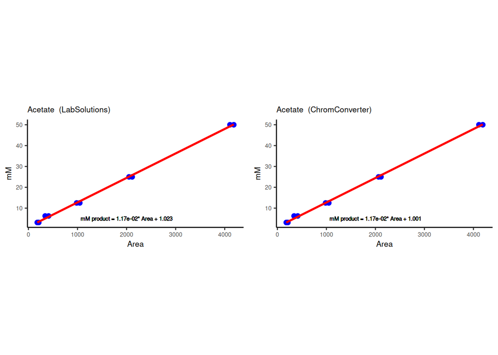

Linear regressions of peak area vs acetate concentration for all standards.

```r
# text placement
text.x = 2e3;
text.y = 5;

plot.reg.ls = ggplot(areas.all.ls, aes(x=Area, y=mM))+
  ggtitle(paste(Compound, " (LabSolutions)"))+
  geom_point(size=2, color = 'blue') +
  geom_smooth(method=lm, se=FALSE, color='red', width=0.1, formula = y ~ x)+
  xlab("Area") +
  ylab("mM") +
  theme_classic() +
  geom_text(x=text.x, y=text.y, label=regtext.ls, size=2)+
  mytheme;

plot.reg.cc = ggplot(areas.all.cc, aes(x=Area, y=mM))+
  ggtitle(paste(Compound," (ChromConverter)"))+
  geom_point(size=2, color = 'blue') +
  geom_smooth(method=lm, se=FALSE, color='red', width=0.1, formula = y ~ x)+
  xlab("Area") +
  ylab("mM") +
  theme_classic() +
  geom_text(x=text.x, y=text.y, label=regtext.cc, size=2)+
  mytheme;

# print regressions
 bothplots = grid.arrange(plot.reg.ls, plot.reg.cc, ncol = 2);
```

### Ethanol

Calc peak areas

```r
# compound parameters
Compound = "Ethanol";
peak.start = 25.75;
peak.end = 27.25;

# get the chromatogram peaks and calculate the areas for each sample
peakData = calc_peakAreas(peak.start, peak.end, data.all);
peaks.all = peakData[[1]];
areas.all = peakData[[2]];

# add standard concentrations to peak areas
standards.compound = standards %>%
  filter(Metabolite == Compound) %>%
  rename(SampleID = Sample);
areas.all.concs = left_join(areas.all, standards.compound, by="SampleID");
```

Calc regressions

```r
# LS data: regression
target.method = "LabSolutions";

areas.all.ls = areas.all.concs %>%
  filter(Method == target.method);

my.lm = lm(mM ~ Area, areas.all.ls);
yint = my.lm$coefficients[1];
myslope = my.lm$coefficients[2];
myslope.text = formatC(myslope, format = "e", digits = 2);
regression.ls = data.frame(Compound, target.method, myslope, yint, peak.start, peak.end);
regressions.out = rbind(regressions.out, regression.ls);
regtext.ls = paste("mM product = ", myslope.text, "* Area + ", round(yint, 3), sep="");

# CC data: regression
target.method = "ChromConverter";
areas.all.cc = areas.all.concs %>%
  filter(Method == target.method);

my.lm = lm(mM ~ Area, areas.all.cc);
yint = my.lm$coefficients[1];
myslope = my.lm$coefficients[2];
myslope.text = formatC(myslope, format = "e", digits = 2);
regression.cc = data.frame(Compound, target.method, myslope, yint, peak.start, peak.end);
regressions.out = rbind(regressions.out, regression.cc);
regtext.cc = paste("mM product = ", myslope.text, "* Area + ", round(yint, 3), sep="");
```

Plot peaks

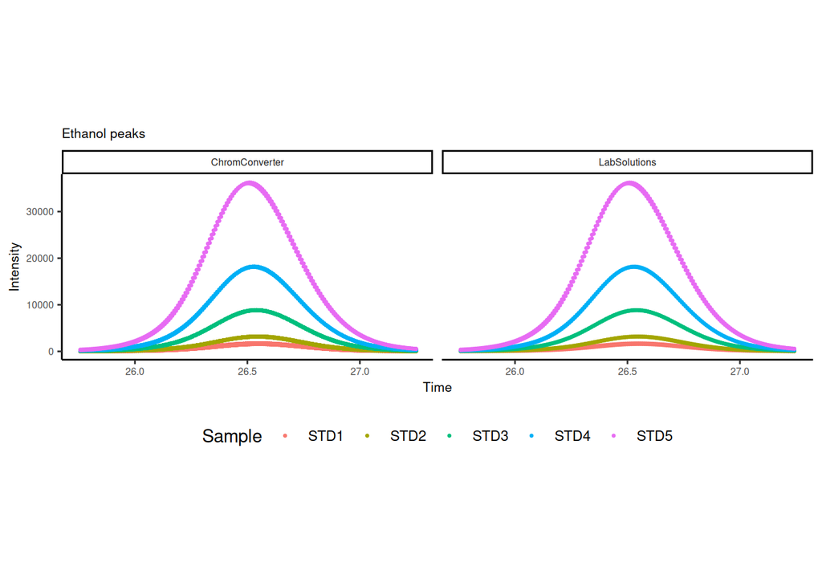

Peak areas of ethanol in each of the standards samples.

```r
# plot peaks
 myplot = ggplot(peaks.all, aes(x=Minutes, y=Intensity, group=Sample, color=Sample)) +
  ggtitle(paste(Compound, " peaks", sep=""))+
  geom_point(size=0.5) +
  xlab("Time") +
  ylab("Intensity") +
  coord_cartesian(xlim=c(peak.start, peak.end), ylim=c(min(peaks.all$Intensity), max(peaks.all$Intensity)))+
  theme_classic() +
  facet_wrap(~ Format)+
  theme_classic()+
  mytheme;

myplot
```

Plot regressions

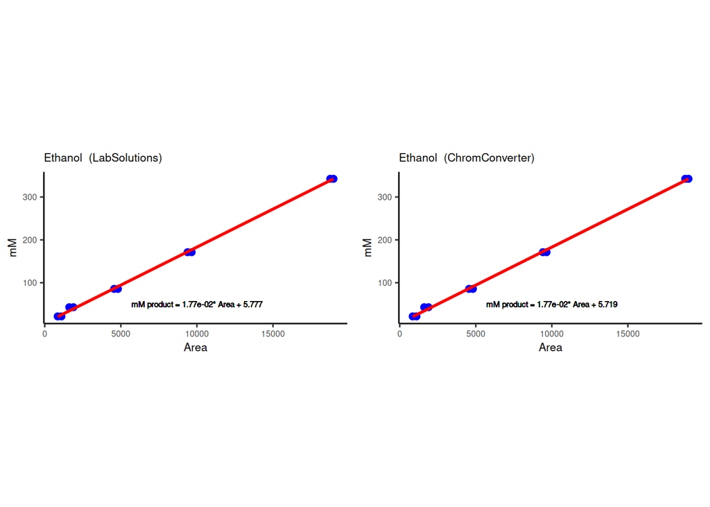

Linear regressions of peak area vs ethanol concentration for all standards.

```r
# text placement
text.x = 10e3;
text.y = 50;

plot.reg.ls = ggplot(areas.all.ls, aes(x=Area, y=mM))+
  ggtitle(paste(Compound, " (LabSolutions)"))+
  geom_point(size=2, color = 'blue') +
  geom_smooth(method=lm, se=FALSE, color='red', width=0.1, formula = y ~ x)+
  xlab("Area") +
  ylab("mM") +
  theme_classic() +
  geom_text(x=text.x, y=text.y, label=regtext.ls, size=2)+
  mytheme;

plot.reg.cc = ggplot(areas.all.cc, aes(x=Area, y=mM))+
  ggtitle(paste(Compound," (ChromConverter)"))+
  geom_point(size=2, color = 'blue') +
  geom_smooth(method=lm, se=FALSE, color='red', width=0.1, formula = y ~ x)+
  xlab("Area") +
  ylab("mM") +
  theme_classic() +
  geom_text(x=text.x, y=text.y, label=regtext.cc, size=2)+
  mytheme;

# print regressions
 bothplots = grid.arrange(plot.reg.ls, plot.reg.cc, ncol = 2);
```

### Lactate

Calc peak areas

```r
# compound parameters
Compound = "Lactate";
peak.start = 14.75;
peak.end = 15.6;
# get the chromatogram peaks and calculate the areas for each sample
peakData = calc_peakAreas(peak.start, peak.end, data.all);
peaks.all = peakData[[1]];
areas.all = peakData[[2]];

# add standard concentrations to peak areas
standards.compound = standards %>%
  filter(Metabolite == Compound) %>%
  rename(SampleID = Sample);
areas.all.concs = left_join(areas.all, standards.compound, by="SampleID");
```

Calc regressions

```r
# LS data: regression
target.method = "LabSolutions";

areas.all.ls = areas.all.concs %>%
  filter(Method == target.method);

my.lm = lm(mM ~ Area, areas.all.ls);
yint = my.lm$coefficients[1];
myslope = my.lm$coefficients[2];
myslope.text = formatC(myslope, format = "e", digits = 2);
regression.ls = data.frame(Compound, target.method, myslope, yint, peak.start, peak.end);
regressions.out = rbind(regressions.out, regression.ls);
regtext.ls = paste("mM product = ", myslope.text, "* Area + ", round(yint, 3), sep="");

# CC data: regression
target.method = "ChromConverter";
areas.all.cc = areas.all.concs %>%
  filter(Method == target.method);

my.lm = lm(mM ~ Area, areas.all.cc);
yint = my.lm$coefficients[1];
myslope = my.lm$coefficients[2];
myslope.text = formatC(myslope, format = "e", digits = 2);
regression.cc = data.frame(Compound, target.method, myslope, yint, peak.start, peak.end);
regressions.out = rbind(regressions.out, regression.cc);
regtext.cc = paste("mM product = ", myslope.text, "* Area + ", round(yint, 3), sep="");
```

Plot peaks

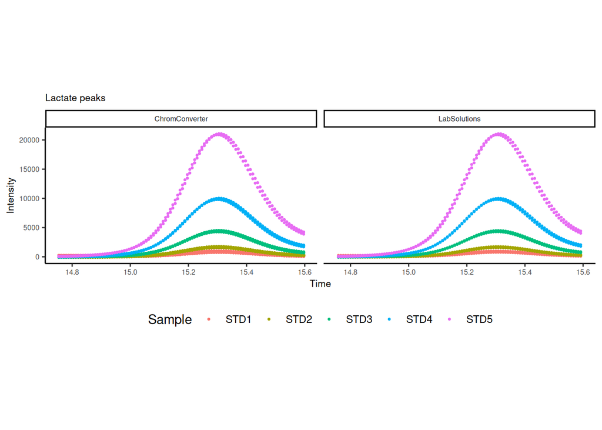

Peak areas of lactate in each of the standards samples.

```r
# plot peaks
 myplot = ggplot(peaks.all, aes(x=Minutes, y=Intensity, group=Sample, color=Sample)) +
  ggtitle(paste(Compound, " peaks", sep=""))+
  geom_point(size=0.5) +
  xlab("Time") +
  ylab("Intensity") +
  coord_cartesian(xlim=c(peak.start, peak.end), ylim=c(min(peaks.all$Intensity), max(peaks.all$Intensity)))+
  theme_classic() +
  facet_wrap(~ Format)+
  theme_classic()+
  mytheme;

myplot
```

Plot regressions

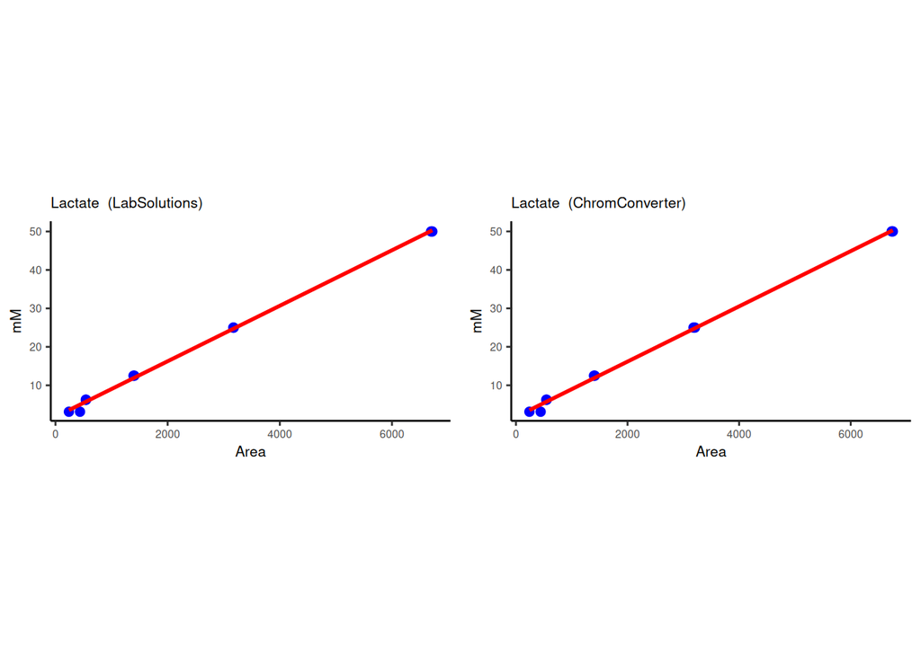

Linear regressions of peak area vs lactate concentration for all standards.

```r
# text placement
text.x = 10e3;
text.y = 50;

plot.reg.ls = ggplot(areas.all.ls, aes(x=Area, y=mM))+
  ggtitle(paste(Compound, " (LabSolutions)"))+
  geom_point(size=2, color = 'blue') +
  geom_smooth(method=lm, se=FALSE, color='red', width=0.1, formula = y ~ x)+
  xlab("Area") +
  ylab("mM") +
  theme_classic() +
  geom_text(x=text.x, y=text.y, label=regtext.ls, size=2)+
  mytheme;

plot.reg.cc = ggplot(areas.all.cc, aes(x=Area, y=mM))+
  ggtitle(paste(Compound," (ChromConverter)"))+
  geom_point(size=2, color = 'blue') +
  geom_smooth(method=lm, se=FALSE, color='red', width=0.1, formula = y ~ x)+
  xlab("Area") +
  ylab("mM") +
  theme_classic() +
  geom_text(x=text.x, y=text.y, label=regtext.cc, size=2)+
  mytheme;

# print regressions
 bothplots = grid.arrange(plot.reg.ls, plot.reg.cc, ncol = 2);
```

### Glucose

Calc peak areas

```r
# compound parameters
Compound = "Glucose";
peak.start = 10.5;
peak.end = 11.5;

# get the chromatogram peaks and calculate the areas for each sample
peakData = calc_peakAreas(peak.start, peak.end, data.all);
peaks.all = peakData[[1]];
areas.all = peakData[[2]];

# add standard concentrations to peak areas
standards.compound = standards %>%
  filter(Metabolite == Compound) %>%
  rename(SampleID = Sample);
areas.all.concs = left_join(areas.all, standards.compound, by="SampleID");
```

Calc regressions

```r
# LS data: regression
target.method = "LabSolutions";

areas.all.ls = areas.all.concs %>%
  filter(Method == target.method);

my.lm = lm(mM ~ Area, areas.all.ls);
yint = my.lm$coefficients[1];
myslope = my.lm$coefficients[2];
myslope.text = formatC(myslope, format = "e", digits = 2);
regression.ls = data.frame(Compound, target.method, myslope, yint, peak.start, peak.end);
regressions.out = rbind(regressions.out, regression.ls);
regtext.ls = paste("mM product = ", myslope.text, "* Area + ", round(yint, 3), sep="");

# CC data: regression
target.method = "ChromConverter";
areas.all.cc = areas.all.concs %>%
  filter(Method == target.method);

my.lm = lm(mM ~ Area, areas.all.cc);
yint = my.lm$coefficients[1];
myslope = my.lm$coefficients[2];
myslope.text = formatC(myslope, format = "e", digits = 2);
regression.cc = data.frame(Compound, target.method, myslope, yint, peak.start, peak.end);
regressions.out = rbind(regressions.out, regression.cc);
regtext.cc = paste("mM product = ", myslope.text, "* Area + ", round(yint, 3), sep="");
```

Plot peaks

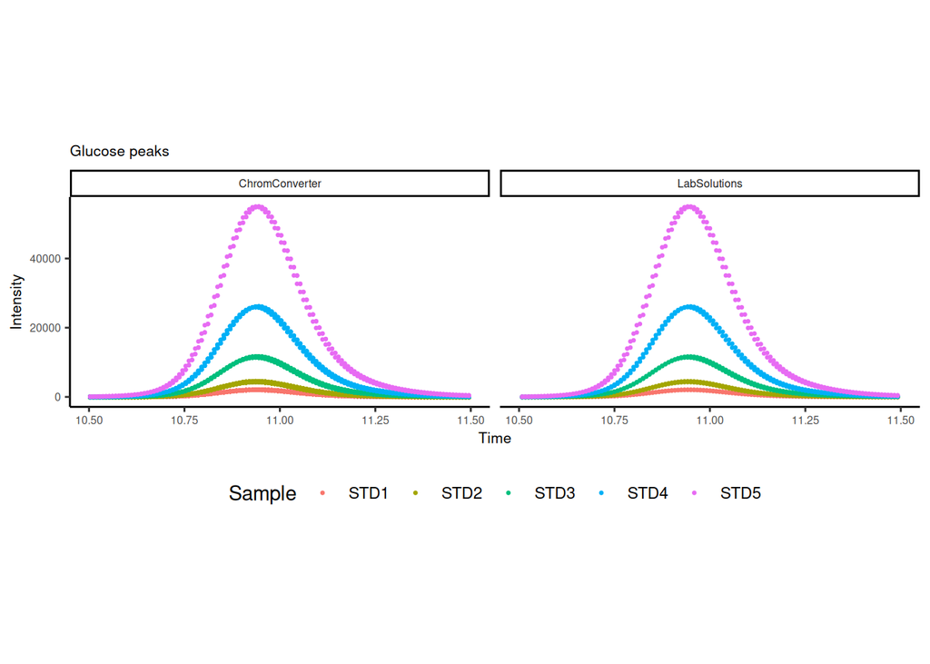

Peak areas of glucose in each of the standards samples.

```r
# plot peaks
 myplot = ggplot(peaks.all, aes(x=Minutes, y=Intensity, group=Sample, color=Sample)) +
  ggtitle(paste(Compound, " peaks", sep=""))+
  geom_point(size=0.5) +
  xlab("Time") +
  ylab("Intensity") +
  coord_cartesian(xlim=c(peak.start, peak.end), ylim=c(min(peaks.all$Intensity), max(peaks.all$Intensity)))+
  theme_classic() +
  facet_wrap(~ Format)+
  theme_classic()+
  mytheme;

myplot
```

Plot regressions

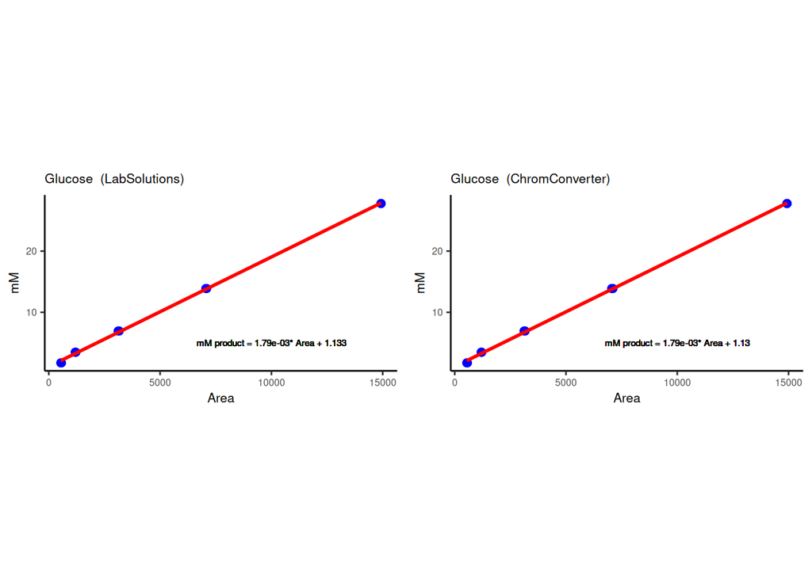

Linear regressions of peak area vs glucose concentration for all standards.

```r
# text placement
text.x = 10e3;
text.y = 5;

plot.reg.ls = ggplot(areas.all.ls, aes(x=Area, y=mM))+
  ggtitle(paste(Compound, " (LabSolutions)"))+
  geom_point(size=2, color = 'blue') +
  geom_smooth(method=lm, se=FALSE, color='red', width=0.1, formula = y ~ x)+
  xlab("Area") +
  ylab("mM") +
  theme_classic() +
  geom_text(x=text.x, y=text.y, label=regtext.ls, size=2)+
  mytheme;

plot.reg.cc = ggplot(areas.all.cc, aes(x=Area, y=mM))+
  ggtitle(paste(Compound," (ChromConverter)"))+
  geom_point(size=2, color = 'blue') +
  geom_smooth(method=lm, se=FALSE, color='red', width=0.1, formula = y ~ x)+
  xlab("Area") +
  ylab("mM") +
  theme_classic() +
  geom_text(x=text.x, y=text.y, label=regtext.cc, size=2)+
  mytheme;

# print regressions
 bothplots = grid.arrange(plot.reg.ls, plot.reg.cc, ncol = 2);
```

### Cellobiose

Calc peak areas

```r
# compound parameters
Compound = "Cellobiose";
peak.start = 8.5;
peak.end = 9.5;

# get the chromatogram peaks and calculate the areas for each sample
peakData = calc_peakAreas(peak.start, peak.end, data.all);
peaks.all = peakData[[1]];
areas.all = peakData[[2]];

# add standard concentrations to peak areas
standards.compound = standards %>%
  filter(Metabolite == Compound) %>%
  rename(SampleID = Sample);
areas.all.concs = left_join(areas.all, standards.compound, by="SampleID");
```

Calc regressions

```r
# LS data: regression
target.method = "LabSolutions";

areas.all.ls = areas.all.concs %>%
  filter(Method == target.method);

my.lm = lm(mM ~ Area, areas.all.ls);
yint = my.lm$coefficients[1];
myslope = my.lm$coefficients[2];
myslope.text = formatC(myslope, format = "e", digits = 2);
regression.ls = data.frame(Compound, target.method, myslope, yint, peak.start, peak.end);
regressions.out = rbind(regressions.out, regression.ls);
regtext.ls = paste("mM product = ", myslope.text, "* Area + ", round(yint, 3), sep="");

# CC data: regression
target.method = "ChromConverter";
areas.all.cc = areas.all.concs %>%
  filter(Method == target.method);

my.lm = lm(mM ~ Area, areas.all.cc);
yint = my.lm$coefficients[1];
myslope = my.lm$coefficients[2];
myslope.text = formatC(myslope, format = "e", digits = 2);
regression.cc = data.frame(Compound, target.method, myslope, yint, peak.start, peak.end);
regressions.out = rbind(regressions.out, regression.cc);
regtext.cc = paste("mM product = ", myslope.text, "* Area + ", round(yint, 3), sep="");
```

Plot peaks

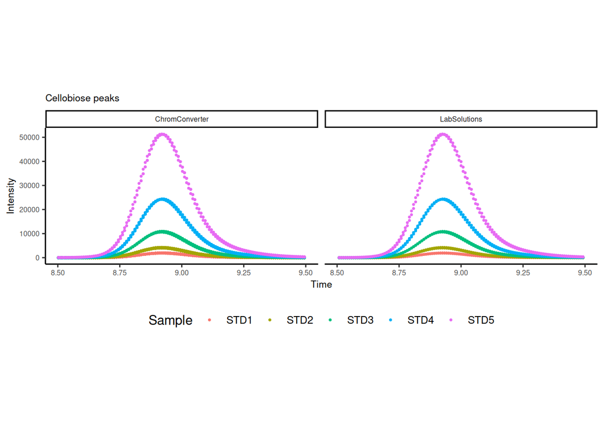

Peak areas of cellobiose in each of the standards samples.

```r
# plot peaks
 myplot = ggplot(peaks.all, aes(x=Minutes, y=Intensity, group=Sample, color=Sample)) +
  ggtitle(paste(Compound, " peaks", sep=""))+
  geom_point(size=0.5) +
  xlab("Time") +
  ylab("Intensity") +
  coord_cartesian(xlim=c(peak.start, peak.end), ylim=c(min(peaks.all$Intensity), max(peaks.all$Intensity)))+
  theme_classic() +
  facet_wrap(~ Format)+
  theme_classic()+
  mytheme;

myplot
```

Plot regressions

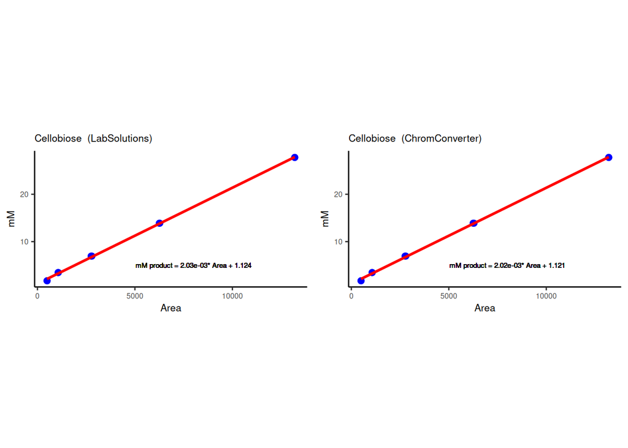

Linear regressions of peak area vs cellobiose concentration for all standards.

```r
# text placement
text.x = 8e3;
text.y = 5;

plot.reg.ls = ggplot(areas.all.ls, aes(x=Area, y=mM))+
  ggtitle(paste(Compound, " (LabSolutions)"))+
  geom_point(size=2, color = 'blue') +
  geom_smooth(method=lm, se=FALSE, color='red', width=0.1, formula = y ~ x)+
  xlab("Area") +
  ylab("mM") +
  theme_classic() +
  geom_text(x=text.x, y=text.y, label=regtext.ls, size=2)+
  mytheme;

plot.reg.cc = ggplot(areas.all.cc, aes(x=Area, y=mM))+
  ggtitle(paste(Compound," (ChromConverter)"))+
  geom_point(size=2, color = 'blue') +
  geom_smooth(method=lm, se=FALSE, color='red', width=0.1, formula = y ~ x)+
  xlab("Area") +
  ylab("mM") +
  theme_classic() +
  geom_text(x=text.x, y=text.y, label=regtext.cc, size=2)+
  mytheme;

# print regressions
 bothplots = grid.arrange(plot.reg.ls, plot.reg.cc, ncol = 2);
```

## Output regression parameters

```r
table.regression = kable(regressions.out, caption = "Table: regression parameters for each metabolite.");
table.regression
```

Table: regression parameters for each metabolite.

|  | Compound | target.method | myslope | yint | peak.start | peak.end |
| --- | --- | --- | --- | --- | --- | --- |
| Area | Acetate | LabSolutions | 0.0117433 | 1.022677 | 17.75 | 18.60 |
| Area1 | Acetate | ChromConverter | 0.0117308 | 1.001077 | 17.75 | 18.60 |
| Area2 | Ethanol | LabSolutions | 0.0177362 | 5.776612 | 25.75 | 27.25 |
| Area3 | Ethanol | ChromConverter | 0.0177283 | 5.719005 | 25.75 | 27.25 |
| Area4 | Lactate | LabSolutions | 0.0072152 | 1.825425 | 14.75 | 15.60 |
| Area5 | Lactate | ChromConverter | 0.0071764 | 1.817722 | 14.75 | 15.60 |
| Area6 | Glucose | LabSolutions | 0.0017906 | 1.132856 | 10.50 | 11.50 |
| Area7 | Glucose | ChromConverter | 0.0017898 | 1.130038 | 10.50 | 11.50 |
| Area8 | Cellobiose | LabSolutions | 0.0020254 | 1.124255 | 8.50 | 9.50 |
| Area9 | Cellobiose | ChromConverter | 0.0020245 | 1.120689 | 8.50 | 9.50 |

```r
write.table(regressions.out, file = "/home/tolonen/Github/actolonen/Public/Analysis_Lab/Metabolites/HPLC/Standards/standards_regressions.tsv", row.names=FALSE, sep="\t")
```

# Conclusions

1. Metabolite quantifications using Lab Solutions .txt files and ChromConverter-transformed .lcd files are highly reproducible. However, Lab Solutions appears to scale their peaks using a simple, linear scaling (here ~3.23). It will be interesting to see if this scaling factor is the same across experiments.
2. Peak areas for all metabolites are linear across the concentrations used in these standards. These methods can thus be applied to quantify metabolites from other samples in this experiment.